# Untitled

Henry Owens

3/7/2021

## Tidying Data

I will look at the following data: * Ecommerce data from New Zealand’s statistics agency Table: B - ICT - Internet sales as a proportion of total sales by Industry (Annual-Aug) http://infoshare.stats.govt.nz/ViewTable.aspx?pxID=18ed91a0-2ea0-4fbf-948c-5663a6611179

- GDP Growth data from the world bank  
  https://data.worldbank.org/indicator/NY.GDP.MKTP.KD.ZG?most_recent_year_desc=true
- Air quality data in London. For this I selected nitric oxide levels detected at three sites: -Barking and Dagenham - Scrattons Farm -Croydon - Park Lane -Brent - Ikea https://www.londonair.org.uk/LondonAir/Default.aspx

## New Zealand Commerce data

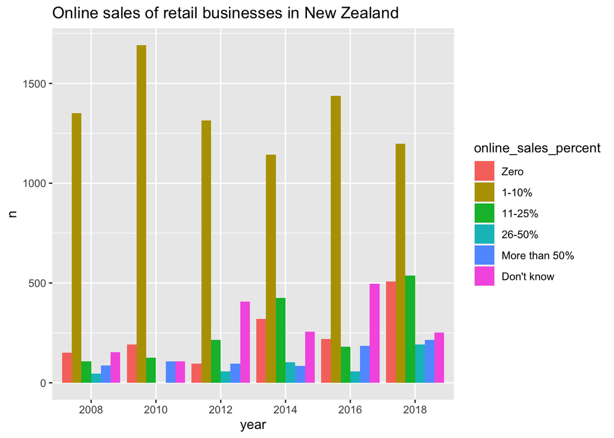

## World Bank GDP Growth Data

```r
url <- "https://raw.githubusercontent.com/hankowens/CUNY-MSDS/main/607/Tidy%20data/API_NY.GDP.MKTP.KD.ZG_DS2_en_csv_v2_2055665.csv"

worldbank <- read.csv(url, header = FALSE)
# Turn the row with years to char
worldbank[3,] <- as.character(worldbank[3,])
# drop first two useless rows
worldbank <- worldbank[-c(1,2),]
#rename header for country
worldbank[1,1] <- "country"
# eliminate years before 2000 (for simplicity)
worldbank <- worldbank[,-c(2:44)]
# set column headers and then delete first row
names(worldbank) <- as.matrix(worldbank[1, ])
worldbank <- worldbank[-1,]
# the last two rows are empty: deleting
worldbank <- worldbank[,-c(ncol(worldbank)-1, ncol(worldbank))]
```

## Pivoting the data to Tidy format

## Running hot

This is a very crude, naive investigation of GDP (because of compounding you shouldn’t average growth rates, etc), but I am curious if there is any relationship between having a high maximum GDP growth and average GDP growth. I wonder about the countries that have 25% or more GDP growth that is probably some kind of statistical anomaly; 125% certainly is. Not sure what to conclude about this but it is interesting.

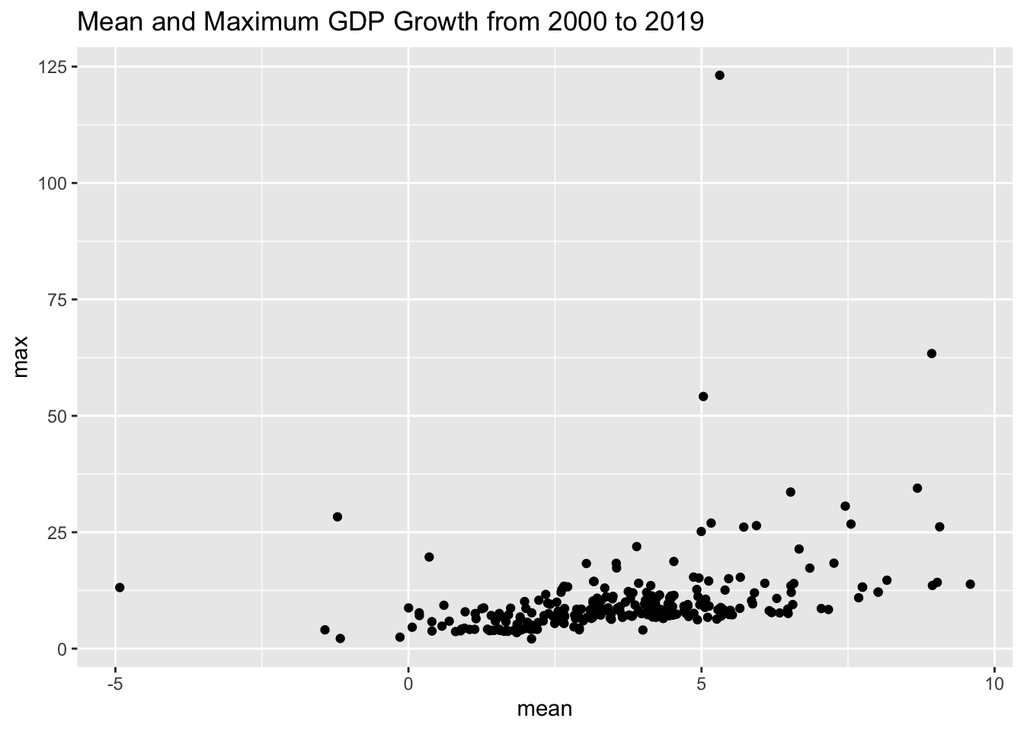

## London Air Quality data

- This data is already in a pretty tidy, long format, but I will transform and analyze it.

```
## # A tibble: 12 x 2
##    month      amount
##    <date>      <dbl>
##  1 2020-01-01   46.5
##  2 2020-11-01   41.4
##  3 2020-02-01   30.1
##  4 2020-12-01   29.9
##  5 2020-09-01   23.3
##  6 2020-10-01   22.8
##  7 2020-03-01   17.9
##  8 2020-06-01   14.3
##  9 2020-08-01   14.3
## 10 2020-07-01   13.5
## 11 2020-04-01   12.6
## 12 2020-05-01   11.0
```

Assuming that whatever nitric oxide chemical we are describing here is bad, it would appear that the winter months are the worse for it.